# STATISTICAL COMPUTING PROJECT

## 11. (2p every item) Multiple Linear Regression

```r
modelMLR <- lm(dFile$GPA ~ dFile$GENDER + dFile$STAY)
summary(modelMLR)
```

```
##
## Call:
## lm(formula = dFile$GPA ~ dFile$GENDER + dFile$STAY)
##
## Residuals:
##     Min      1Q  Median      3Q     Max
## -59.526 -14.730  -0.214  15.075  43.506
##
## Coefficients:
##              Estimate Std. Error t value Pr(>|t|)
## (Intercept)   59.2752     0.9751  60.790  < 2e-16 ***
## dFile$GENDER  -4.4913     1.1980  -3.749 0.000187 ***
## dFile$STAY     0.2504     1.1786   0.212 0.831760
## ---
## Signif. codes:  0 '***' 0.001 '**' 0.01 '*' 0.05 '.' 0.1 ' ' 1
##
## Residual standard error: 19.61 on 1116 degrees of freedom
## Multiple R-squared:  0.01244,    Adjusted R-squared:  0.01067
## F-statistic: 7.027 on 2 and 1116 DF,  p-value: 0.0009272
```

```r
# Approximately (Multiple R-squared:  0.01244) 1% of variation in GPA can be explained by our modelMLR (GENDER + STAY)

# This tests the Null Hypothesis that all the modelMLR coefficients are 0 (F-statistic: 7.027 on 2 and 1116 DF,  p-value: 0.0009272)

# H0: Bgender=Bstay=0

# Gives on idea of how far observed GPA (y values) are from the predicted or fitted GPA (Residual standard error: 19.61 on 1116 degrees of freedom)

# Calculate Pearson's correlation between Gender and Stay
cor(dFile$GENDER, dFile$STAY, method = "pearson")
```

```
## [1] 0.05559987
```

```r
# Ask for confidence intervals for the model coefficients
confint(modelMLR, conf.level=0.95)
```

```
##                  2.5 %    97.5 %
## (Intercept)  57.362018 61.188424
## dFile$GENDER -6.841911 -2.140656
## dFile$STAY   -2.062097  2.562994
```

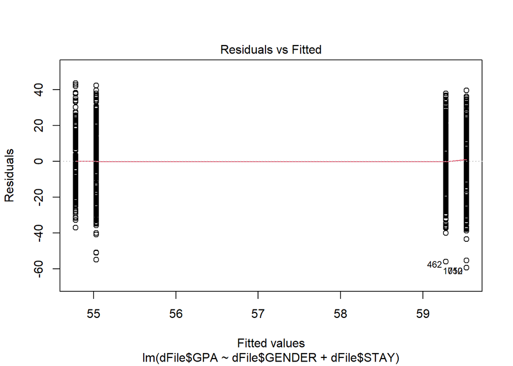

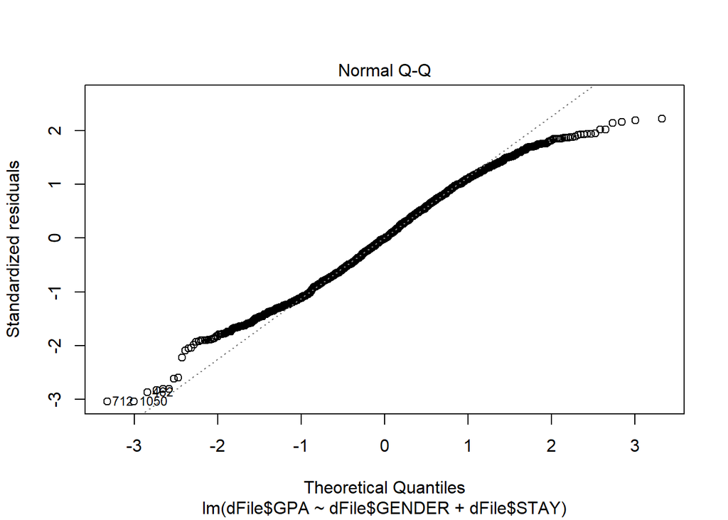

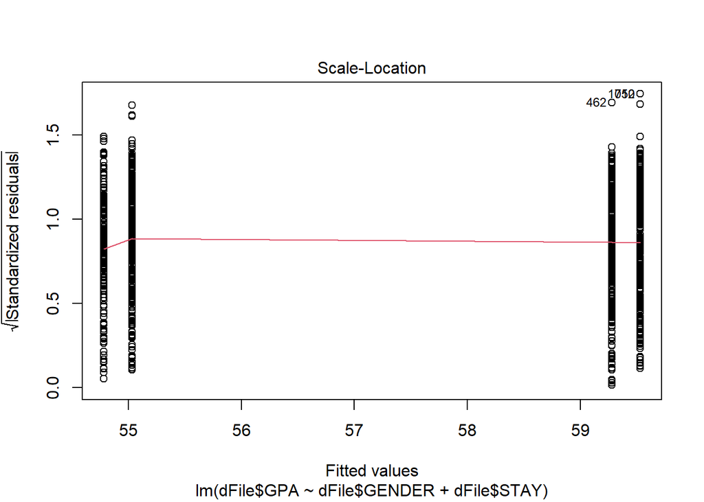

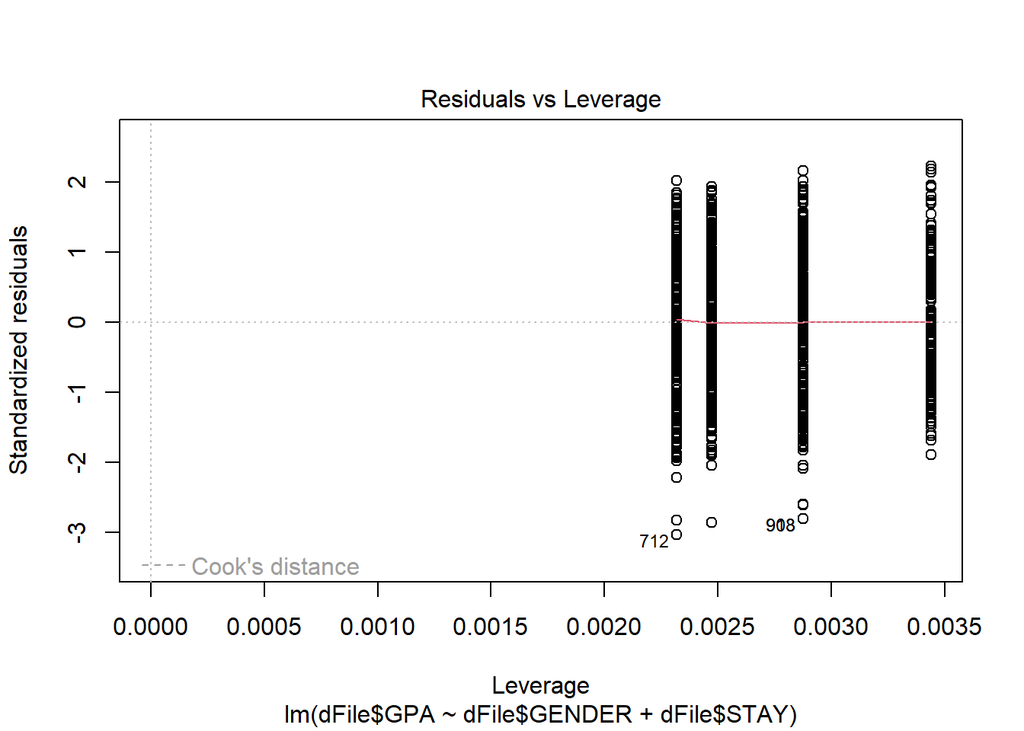

```r
plot(modelMLR)
```

1. Aim  
   In words, what is your objective here?

**We examined the linear correlation between GPA dependent variable and GENDER and STAY independent variables with Multiple Linear Regression.**

2. Regression Equation:  
   Multiple linear regression (MLR) is a statistical technique that uses several explanatory variables to predict the outcome of a response variable. Which ones are your explanatory variables and which one is your response variable? Write down the equation of your regression using those variables.

3. Hypothesis and level of significance:  
   Write your hypothesis in scientific form and determine the level of significance.

4. Find the Best Model:  
   Use step function and find the best model, describe the reason which makes it the best one.

5. Assumption Check:  
   Check the required assumptions, “comment on each of them is a must!”.

**(F-statistic: 7.027 on 2 and 1116 DF, p-value: 0.0009272) Since p-value<0.5, there is a linear dependence between the variables.**

6. Result:  
   Give the output of the best model and write down the result.

7. Conclusion:  
   You got your result in item f. Write down the conclusion of your result, in such a way that, the reader who doesn’t know any statistics can understand your findings.

8. Prediction:  
   Think of a new X variable, or variables (just make it up). Use your best model in order to predict the new Y variable for those X variables.

**If a new variable such as the student’s weight was added to our dataset, this would not have an effect on the GPA. We could use the stepwise model for this.**